# Video 1: PyMC3 Sampling

# Video 3: Introduction to Arviz

The Bayesian workflow is more than just specifying the model and running inference. Certainly those are the most notable components but just specifying models and generating samples do not constitute everything that could be useful in a full Bayesian workflow.

### Question 1: What does the Arviz package do?

So ArviZ fits in for the other things - it is a Python package for visualization in Bayesian workflow. It fits in for evaluating the prior distributions, it helps us evaluate sample diagnostics and it helps summarize the posterior distribution or model fit.

### Question 2: Why do we need Arviz during the process of performing Bayesian analysis?

In PyMC3 we've looked at the traceplot (well Arviz also provides that), but we definitely need more visualizations to help characterize some uncertainty for whatever problems that we are working on.

### Question 3: Where could we find out documentation and recent updates about the Arviz package?

- Documentation: https://arviz-devs.github.io/arviz/
- Gallary: https://arviz-devs.github.io/arviz/examples/index.html

### Question 4: How does Arviz help fulfill the 4-step Bayesian analysis?

So the whole point of the Arviz Python package is to help organize data to make complex calculations much much easier for everybody. It helps us look inside the shape of the prior distributions and explore posterior results by performing more diagnostics on it after simulating the model in PyMC3.

```
array([<AxesSubplot:title={'center':'theta_google'}>,
       <AxesSubplot:title={'center':'theta_yahoo'}>], dtype=object)
```

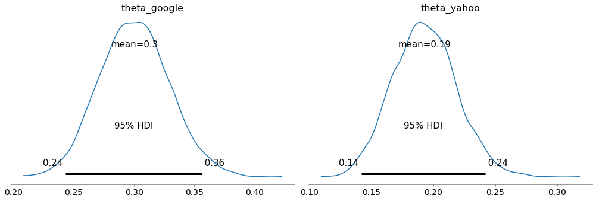

```python
# In this case, we are loading the diagnostic data from the 3 chains of 2000 samples of online advertising
# click-through rate. Let's import the Arviz library.
import arviz as az

# The first visualization which is useful for diagnosis is called the plot_posterior.
# We can create a highest posterior density plot for each provider regarding the click
# through rate by passing through the trace object, and setting the posterior probability to 0.95.
az.plot_posterior(trace , hdi_prob = 0.95)
# Here we get a distribution of the posterior click through rate right here for Google on the
# left panel, and Yahoo on the right panel. Both graphs are almost symmetric and we'll see the click-through
# rate of both providers are narrow intervals.
# Particularly, the most probable 95% falls between 0.24 and 0.36 for Google, and between 0.14 and 0.24
# for Yahoo, so no more than 40% of ads will receive a visit after watching. It barely happens.
```

Here we conclude the short Arviz tutorial! Most of the tricks of using Arviz are nothing more than importing the package and applying one of the various Arviz functions that are available in the Arviz gallery (https://arviz-devs.github.io/arviz/examples/index.html). I encourage you to dive into some Arviz plots and reading these may help you choose the best visualization to interpret results to various target audiences.

# Optional Video: Cost Distribution

Now we've explored the PyMC3 and the Arviz packages in Python. Both packages are important in this course because they support Bayesian modeling from planning the analysis, to executing models and interpreting posterior results. Now let's come back to the beginning. Our research question is **Can we utilize the data about whether a user clicked into an advertisement or not and the advertisement provider to predict the cost that a company needs to offer online advertisement to reach 10,000 users?** Let's rewrite a bit about the model and this time we aim to find the cost distribution for each provider.

```python
# From the dataset we know that the cost for online advertisement is 0.3 per impression.
online_ads['cost']
cost = 0.3
```

```python
# We again start off by defining a context manager using the pm.Model() argument and call the model
# cost_distribution.

with pm.Model() as cost_distribution:

    # We'll use the same prior distribution for Google and Yahoo advertising providers regarding the
    # click through rate
    theta_google = pm.Beta('theta_google', alpha = 25, beta = 75)
    theta_yahoo = pm.Beta('theta_yahoo', alpha = 25, beta = 75)

    # Awesome! The next step is calculating the cost distribution for each provider. Because the number
    # of impressions is not exactly the amount of users the advertisement reaches, you need to divide the
    # number of users reached (here is 10,000) by the click through rate in order to find out how many
    # impressions are needed to reach that amount of users. With that said, the lower the click
    # through rate is, the more impressions are needed in order to reach 10,000 users. So the
    # cost distribution is then calculated by multiplying the cost of each advertisement impression
    # times 10,000 (which is the target user outreach) divided by the click-through-rate we have.
    # That is, theta_google for Google, and theta_yahoo for Yahoo.
    cost_google = pm.Deterministic('cost_google', cost * 10000 / theta_google)
    cost_yahoo = pm.Deterministic('cost_yahoo', cost * 10000 / theta_yahoo)

    # How about the likelihood? In this case, we don't need to change anything and still measure click
    # through rate using the binary data. Remember that you get an impression and you hit on
    # a specific website links with the probability given by theta_google, and theta_yahoo.
    # So we use the pm.Bernoulli function here to model each individual, binary click-through indicator
    # by passing the prior probability and the two arrays of observed click-through data called
    # click_google and click_yahoo.
    google = pm.Bernoulli('google',p=theta_google, observed=click_google)
    yahoo = pm.Bernoulli('yahoo',p=theta_yahoo, observed=click_yahoo)

    # The next step is, how do you get posterior distributions? Because the first model we implemented was
    # totally in good shape, in which all the trajectories converge to a certain number, we can use the same
    # pm.sample argument. But for a tutorial purpose, let's customize a bit for the sampling condition.
    # This time let's determine that the number of samples we want to get for each trajectory is 5,000, so we change
    # the first argument to 5,000. Since we haven't talked about the tune option yet, including 1000 tune samples
    # means that the model will first draw a thousand samples and discard them from analysis, before drawing
    # another 5000 samples that will show in the posterior diagnostics. So this option helps us to discard
    # the first n samples from the model that otherwise the model might fluctuate unpredictably at the
    # beginning of the trajectory. Finally, let's still simulate 3 crews of users engaging in Google, and
    # Yahoo advertisements separately.
    trace = pm.sample(5000, tune=1000, chains = 3)
```

```
Sampling 3 chains for 1_000 tune and 5_000 draw iterations (3_000 + 15_000 draws total) took 19 seconds.
```

# Solution:

Great! Now the trace object includes everything, including the expected cost needed for an organization to launch an online advertisement to 10,000 users.

```
array([[<AxesSubplot:title={'center':'theta_google'}>,
        <AxesSubplot:title={'center':'theta_google'}>],
       [<AxesSubplot:title={'center':'theta_yahoo'}>,
        <AxesSubplot:title={'center':'theta_yahoo'}>],
       [<AxesSubplot:title={'center':'cost_google'}>,
        <AxesSubplot:title={'center':'cost_google'}>],
       [<AxesSubplot:title={'center':'cost_yahoo'}>,
        <AxesSubplot:title={'center':'cost_yahoo'}>]], dtype=object)
```

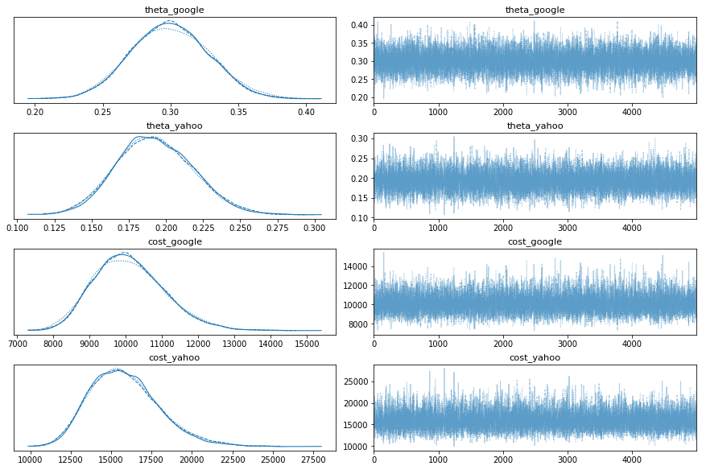

```python
pm.traceplot(trace)

# From the right hand size we see that all click through rates or the cost distribution for online
# advertisement appear to converge really well in all simulation chains. So it's nice as we
# don't need to be rerun the model with different model specifications.

# Now look at the left-hand side, which are density plots for the posterior distribution of click
# through rate and cost distribution for Google and Yahoo providers. We can see that the posterior click
# through rates for both providers seem to be quite symmetric with the highest point located at
# 0.3 and around 0.2 respectively. But if you look at the cost distributions, both graphs show a long
# tail at the upper end, which suggest that the posterior cost distributions are likely to be right skewed.
```

```
array([<AxesSubplot:title={'center':'theta_google'}>,
       <AxesSubplot:title={'center':'theta_yahoo'}>,
       <AxesSubplot:title={'center':'cost_google'}>,
       <AxesSubplot:title={'center':'cost_yahoo'}>], dtype=object)
```

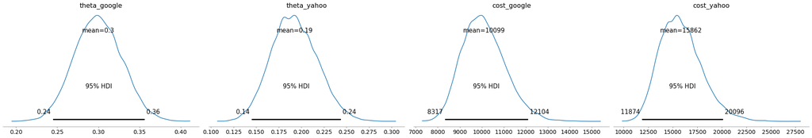

```python
# Now let's zoom into interpreting the highest posterior density of the cost distribution.
# We should call the plot_posterior function in Arviz and set hdi_prob to 0.95 to produce
# 95% highest posterior density plots.
az.plot_posterior(trace, hdi_prob = 0.95)

# Interpretation 1: Cost Distribution
# Cool! At the end of the day we know that we are expected to spend around 10,000 bucks to the Google engine
# for online advertising if we were trying to reach 10,000 users, but how about Yahoo? It's quite different.
# Instead of spending 10,000, we need to pay up to slightly less than 16,000 bucks to the Yahoo engine
# in order to reach the same amount of users.

# Interpretation 2: Cost-effectiveness
# Seeing the plot you might want to recommend using the Google engine because it's more cost-effective
# compared to using the yahoo engine. Let's look at the right tail of the 95% highest posterior density
# plot for Google, you can see the cost 12,104 is actually larger than the left tail of the 95% highest
# posterior density plot for Yahoo, which is 11,874. What it tells us is that there are overlaps between
# the two posterior cost distributions, so we still fall short in concluding that the Google engine
# is more cost-effective in terms of online advertising than Yahoo with substantial evidence.
```

(in-class activity: In your perspective, what different research questions do you find interesting in online advertising? Here is the time you can propose alternative questions. You're more than welcome to write down and compare your questions with your peers!)

From this example, we found that one of the most salient advantage of using PyMC3 is that the model diagnostics not only returns the posterior cost distributions here for both online ads providers, but also helps us quantify the variability of both posterior distributions especially on both tails, thus yielding more realistic predictions. Noticed that the dataset that I collected for both engines was just taken from a short timespan so it might not represent the historical trend about the online advertisement cost for both engines. If some of you do encounter online advertisement problems as a data scientist or consultant, you might need more advanced longitudinal data to determine which search engines will best suit your client.

[figure not shown]

Created in Deepnote